# BMIN-GA 1005 Programming for Data Analysis: Functions

Fred LaPolla

7/14/2022

```r
knitr::opts_chunk$set(echo = TRUE)
```

# Functions

## Review

- What data structure is most like a spreadsheet, with columns and rows containing different types of data?
- What differentiates a matrix from a dataframe?
- How can you look up what type of data structure you are working with?
- What type of data is most appropriate for storing different groups or categories?

## Pulling in last week’s data

```r
nyc <- read.csv("https://raw.githubusercontent.com/fredlapolla/RVilcekMasters2021/main/NYC_HANES_DIAB.csv")
nyc$AGEGROUP <- factor(nyc$AGEGROUP, levels = 1:3, labels = c("Youngest", "Middle", "Aged"))
nyc$GENDER <- factor(nyc$GENDER, levels = 1:2, labels = c("male", "female"))
# Rename the HSQ_1 factor for identification
  nyc$HSQ_1 <- factor(nyc$HSQ_1, levels = 1:5, labels=c("Excellent","Very Good","Good", "Fair", "Poor"))
  # Rename the DX_DBTS as a factor
  nyc$DX_DBTS <- factor(nyc$DX_DBTS,levels = 1:3, labels=c("Diabetes with DX","Diabetes with no DX","No Diabetes"))
```

## Functions

When we work with R, we will call functions to do things to our data, which can include transforming the way the data is set up to make it easier to work with, running analyses on our data or making visualizations.

Earlier we did a basic function:

```r
mean(1:10)
```

```
## [1] 5.5
```

Or another:

```r
class(nyc)
```

```
## [1] "data.frame"
```

## Functions

Functions will take some data object and do something to it. They can take multiple **arguments.** Arguments are the part of a function that specify what needs to be done, and they can be simple or complex.

A function like mean can sometimes work with one argument, the vector that you are taking the mean of. To see what other arguments it takes, we can run:

```r
?mean
```

```
## starting httpd help server ... done
```

## Functions and Arguments

We can see that mean takes three main arguments: x, “an R object” basically the numbers you want the mean of. x is the only manadatory argument. Trim, a fraction that trims from either end of the vector of numbers being averaged. na.rm removes any NAs. This is important because mean cannot run with NAs.

## Arguments

How can you know when arguments are required or not?

Honestly this is mostly through trial and error and copying how others code their functions.

## Functions

You can write your own functions and name them:

```r
doubleMeanFunc <- function(n){mean(n)*2}
n <- 1:10
mean(n)
```

```
## [1] 5.5
```

```r
doubleMeanFunc(n)
```

```
## [1] 11
```

The general format is function(x,y){**some command**}. You do not have to have multiple variables.

## Repeating functions

If we were to try to get the mean of each numeric variable we *could* do something like this:

```r
mean(nyc[,6], na.rm = TRUE)
mean(nyc[,7], na.rm = TRUE)
mean(nyc[,8], na.rm = TRUE)
```

```
## [1] 139.205
## [1] 32.88491
## [1] 31.27413
```

But it may be too time consuming and messy to write the code this way, analyze column by column, especially if we are having a large set of variables to go over.

## Apply

You can run a function across a series of columns or rows. There is a whole family of these commands: apply() These functions allow to manipulate slices of data from matrices, arrays, lists and dataframes in a repetitive way.

Apply() is a command to run a function over several rows or columns. Some R experts say that apply is faster than “for loops” in R, and that it works more efficiently with your data. You must provide the following arguments:

1. The dataframe over which you want to run the function
2. Whether you want to run the function by rows or columns.
3. The function you want to run over those

## apply(), The General Format:

```r
apply(X, MARGIN, FUN, ...)
```

X is an array or a matrix

MARGIN is a variable defining the dimension along the function is applied

FUN, which is the function that you want to apply to the data. (built-in or custom)

## Using apply to get means

```r
apply(nyc[,6:9],2, mean, na.rm = TRUE)
```

```
## UCREATININE    UALBUMIN        UACR    MERCURYU
## 139.2049689  32.8849127  31.2741264   0.8140581
```

#### Thing to be aware of…

Apply converts any data.frame into a matrix (and therefore all values to the same datatype) Whenever the range includes any non-numeric columns, all the results are yielding NAs:

```r
apply(nyc[,1:3], 2, class)
```

```
##         KEY      GENDER       SPAGE
## "character" "character" "character"
```

```r
apply(nyc[,9:11], 2, class)
```

```
##    MERCURYU     DX_DBTS         A1C
## "character" "character" "character"
```

```r
apply(nyc[,1:3], 2, mean, na.rm = TRUE)
```

```
##    KEY GENDER  SPAGE
##     NA     NA     NA
```

```r
apply(nyc[,9:11], 2, mean, na.rm = TRUE)
```

```
## MERCURYU  DX_DBTS      A1C
##       NA       NA       NA
```

## Group Work Apply

A Z Score is a standardized measure of how far a value is from the mean, in standardized units. The equation is

Z = (x - mu)/sd

or the observation (i.e. the value in a cell) - the mean of the column or variable, divided by the standard deviation.

Try using apply to calculate first the standard deviation, then the mean of Lead, total blood mercury, HDL and total cholesterol.

Then using these values try to find the Z score of each cell in these columns.

## Sapply

sapply() is a relatively simple option that runs on columns meaning you don’t need to specify the margin and returns a vector or matrix:

```r
sapply(nyc[,6:9], mean, na.rm = T)
```

```
## UCREATININE    UALBUMIN        UACR    MERCURYU
## 139.2049689  32.8849127  31.2741264   0.8140581
```

There are many of these apply functions that you may enounter, mapply, vapply, lapply. Remember when you encounter that you can use the ?mapply command to look them up and stackoverflow to see differences.

## To Mentimeter

## If Statements and For Loops

### For loops

A common approach to the same problem of running a command over many rows of data in coding is to use **loops**. One way to implament loops in R is by using the `for` statement.

## Syntax of `for` loop

```r
  for (val in sequence)
  {
  statement
  }
```

Where, `sequence` is a vector of elements, not neccessarily sequential. `val` is the name of the variable that gets its current value from the n<sup>th</sup> element in `sequence`. Note: the parentheses are not optional!

In a typical `for` loop you tell R “for every instance of some element in a set, do something.” Here we will tell R to multiply a variable by 3 for every number between 1 and 10.

```r
for (i in 1:10)
{
  i <- i*3
  print(i)
}
```

```
## [1] 3
## [1] 6
## [1] 9
## [1] 12
## [1] 15
## [1] 18
## [1] 21
## [1] 24
## [1] 27
## [1] 30
```

## For loops for getting means like above

Apply functions work similar to for loops. R people tend to say that For Loops are less efficient in R.

```r
for( i in 6:9) {
  value <- mean(nyc[,i], na.rm = TRUE)
  print(c(colnames(nyc[i]), value))
}
```

```
## [1] "UCREATININE"      "139.204968944099"
## [1] "UALBUMIN"         "32.8849126819127"
## [1] "UACR"             "31.2741263774747"
## [1] "MERCURYU"          "0.814058095196733"
```

Note that R did not store these in any sort of table, each line is essentially overwriting the previous.

## Using `for` with variables in your data

We can use these for loops to iterate through each row of our data. Here we will limit to 100 rows to lessen the run-time. We will define a new variable, ‘CHOLRAT’ that holds the ‘Relative CHOLESTEROL by HDL’ index

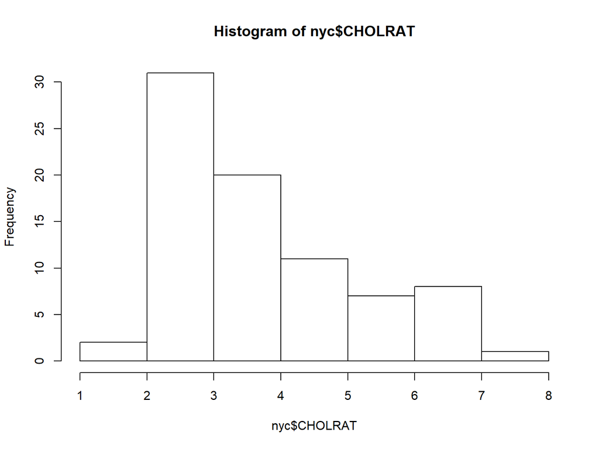

```r
for (i in 1:100) {
    nyc[i, "CHOLRAT"] <- nyc[i, "CHOLESTEROLTOTAL"] / nyc[i, "HDL"]
}
hist(nyc$CHOLRAT)
```

We are telling R that for each row, divide the total cholesterol, by HDL, put that new information into a new column (at the end of our dataframe) then plot the resulting data.

## When you should prefer `for` over `apply`?

- If you want to have full control about how the calculation is being done (e.g. debug it)
- Working on data with a complex nested structure
- Loops are more robust for recycling errors!

## Vectorization

Some of the examples we showed are far less efficient then possible since R is designed to run element by element vectorized calculations.

For example:

```r
for(i in 1:10){
  i <- i*3
  print(i)
}
```

```
## [1] 3
## [1] 6
## [1] 9
## [1] 12
## [1] 15
## [1] 18
## [1] 21
## [1] 24
## [1] 27
## [1] 30
```

The calculation itself is done simply by:

```r
i <- 1:10
i*3
```

```
##  [1]  3  6  9 12 15 18 21 24 27 30
```

Where the scalar 3 is recycled into an equal sized vector as i

In this case it is just the printing that gives a different output

## Examples of variables initialization / memory allocation

```r
# vector() allows to initialize a vast renge of vectors, with different data types and structures
vector(mode = "numeric", length = 99)
```

```
##  [1] 0 0 0 0 0 0 0 0 0 0 0 0 0 0 0 0 0 0 0 0 0 0 0 0 0 0 0 0 0 0 0 0 0 0 0
## [36] 0 0 0 0 0 0 0 0 0 0 0 0 0 0 0 0 0 0 0 0 0 0 0 0 0 0 0 0 0 0 0 0 0 0 0
## [71] 0 0 0 0 0 0 0 0 0 0 0 0 0 0 0 0 0 0 0 0 0 0 0 0 0 0 0 0 0
```

```r
# Matrix initialization
matrix(rep(0, 12), nrow = 4)
```

```
##      [,1] [,2] [,3]
## [1,]    0    0    0
## [2,]    0    0    0
## [3,]    0    0    0
## [4,]    0    0    0
```

```r
testvec <- vector("numeric", length = 3)
 for( i in 6:8){


           testvec[i-5] <- (sd(nyc[,i], na.rm = T))
 }
names(testvec)<-names(nyc[,6:8])
testvec
```

```
## UCREATININE    UALBUMIN        UACR
##    86.90404   212.38956   215.18455
```

## Back to Mentimeter

## Ifelse

Ifelse can be useful for conditional variables, for example when dichotomizing a variable.

```r
nyc <- na.omit(nyc)
for(i in 1:1523){ifelse(nyc$CHOLESTEROLTOTAL[i] > 200, nyc$HiChol[i] <- 1, nyc$HiChol[i] <- 0)}
```

## Group Work

Create a dichotomous variable of diabetes diagnosis, so either has a diabetes or not (collapsing from three groups to two).

## Tidy Data

Often the data we have to work with needs to be organized in some way, for example we may only want a subset or be interested in certain values. While this can be done using indexing and if statements, R has packages that make it easier to do this.

One is the Tidyverse, which is actually a collection of R packages.

## Subsetting with Tidy Data

A good option is called filter for getting a subset. Let’s say we are only interested in the Youngest age group of our nyc data. We can try:

```r
library(tidyverse)
youths <- filter(nyc, AGEGROUP == "Youngest")
```

## Operators in R

R works with multiple operators in these equations:

== means is equal to. One equal sign is used to assign values (like <-), and as an argument feature in some functions (size = 10).

(ignore the quote mark below, it is for formatting only)

’> greater than

’>= great than or equal to

’< less than

’<= less than or equal to

&& And

|| Or

!= Not equal to.

## On your own

Make a filtered subset of straing to only contain the aged group nyc using tidyverse’s Filter command.

The **by()** function: apply a function to a data frame split by factors

The general format:

````
```by(data, INDICES, FUN)```
````

INDICES is a factor or list of factors

```r
by(nyc$UACR, nyc$DX_DBTS, mean, na.rm = TRUE)
```

[output not shown]

## Use of filter and operators

You can combine these terms with the filter command to make subsets that meet certain criteria. Maybe you would only want gene expression levels above some threshold. In this case try filtering to only work with high cholesterol individuals, over 200.

## Select

Often we may want to combine commands. An example of this is to choose a single column of a dataframe to run some analysis on it.

In the Tidyverse, a nice feature is a command called a pipe:

%>%

The pipe takes whatever is to the left of it and runs it into the command to the right, which can cut down on the complexity of nested statements:

```r
YoungLead <- nyc %>% filter(AGEGROUP == "Youngest") %>%  select(LEAD) %>% unlist()
mean(YoungLead, na.rm = TRUE)
```

```
## [1] 1.109797
```

## Select

In practical terms this could be convenient if we wanted to get two subsets to compare with a T Test or some other metric.

## Group Work: Use of filter and operators

You can combine these terms with the filter command to make subsets that meet certain criteria. Try out getting only the males with diabetes in this using filter.

## BioConductor

Many bioinformatics tasks, incuding rna sequence analysis, will use packages from an organization called Bioconductor.

In my experience, install.packages() does not work well with bioconductor. Instead, google the bioconductor package:

Find the package you are interested in and copy their instructions:

```r
if (!requireNamespace("BiocManager", quietly = TRUE))
    install.packages("BiocManager")

BiocManager::install("Biobase")
```